# R Notebook

## T tests and Wilcoxon Signed Rank Tests

Restoring the data set to the Terry Collection with both genders.

```r
DelPrete <- read_excel("Delprete.xlsx")

# Changning data into a data frame

DelPrete <- as.data.frame(DelPrete)

DelPreteT <- subset(DelPrete, Collection_number != 1)
DelPreteT <- subset(DelPreteT, Collection_number != 2)
DelPreteT <- subset(DelPreteT, Collection_number != 3)
```

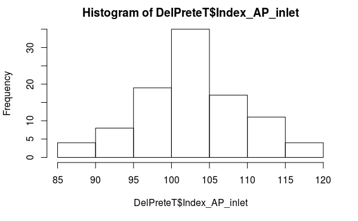

```r
hist(DelPreteT$Index_AP_inlet)
```

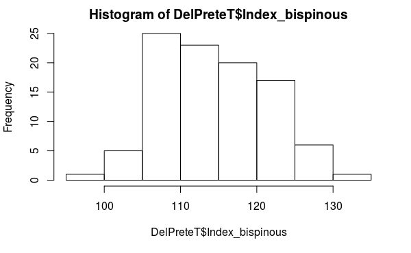

```r
hist(DelPreteT$Index_bispinous)
```

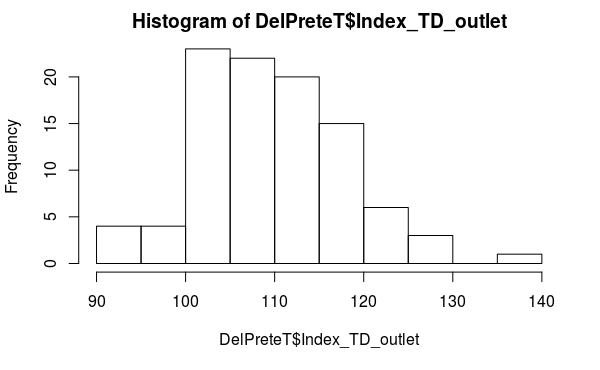

```r
hist(DelPreteT$Index_TD_outlet)
```

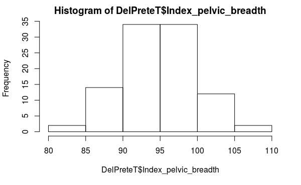

```r
hist(DelPreteT$Index_pelvic_breadth)
```

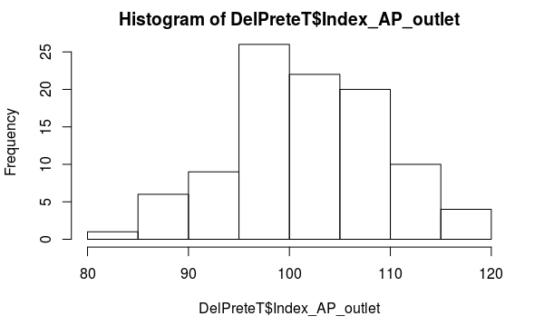

```r
hist(DelPreteT$Index_AP_outlet)
```

The AP Inlet and Pelvic Breadth index values are the only two which is normally distributed, so we can use a t test. The responses are not normally distributed so we have to use a non parametric test.

```r
?t.test
t.test(DelPreteT$Index_AP_inlet ~ DelPreteT$Ethnicity)
```

```
    Welch Two Sample t-test

data:  DelPreteT$Index_AP_inlet by DelPreteT$Ethnicity
t = 0.53506, df = 95.447, p-value = 0.5939
alternative hypothesis: true difference in means is not equal to 0
95 percent confidence interval:
 -1.997273  3.471222
sample estimates:
mean in group B mean in group W
       103.1919        102.4550
```

```r
t.test(DelPreteT$Index_pelvic_breadth ~ DelPreteT$Ethnicity)
```

```
    Welch Two Sample t-test

data:  DelPreteT$Index_pelvic_breadth by DelPreteT$Ethnicity
t = -2.5187, df = 95.196, p-value = 0.01345
alternative hypothesis: true difference in means is not equal to 0
95 percent confidence interval:
 -4.0508172 -0.4798135
sample estimates:
mean in group B mean in group W
       93.67232        95.93763
```

Since the p-value for the AP Inlet is greater than 0.05 we cannot conclude that there is a statistical difference between the mean AP Inlet index value of the races of the Terry collection. Since the p-value for the Pelvic Breadth is less than 0.05 we can conclude that there is a statistical difference between the mean Pelvic Breadth index value of the races of the Terry collection.

```r
wilcox.test(DelPreteT$Index_bispinous ~ DelPreteT$Ethnicity)
```

```
    Wilcoxon rank sum test with continuity correction

data:  DelPreteT$Index_bispinous by DelPreteT$Ethnicity
W = 1122, p-value = 0.5818
alternative hypothesis: true location shift is not equal to 0
```

```r
wilcox.test(DelPreteT$Index_TD_outlet ~ DelPreteT$Ethnicity)
```

```
    Wilcoxon rank sum test with continuity correction

data:  DelPreteT$Index_TD_outlet by DelPreteT$Ethnicity
W = 1410, p-value = 0.1365
alternative hypothesis: true location shift is not equal to 0
```

```r
wilcox.test(DelPreteT$Index_AP_outlet ~ DelPreteT$Ethnicity)
```

```
    Wilcoxon rank sum test with continuity correction

data:  DelPreteT$Index_AP_outlet by DelPreteT$Ethnicity
W = 1599, p-value = 0.004626
alternative hypothesis: true location shift is not equal to 0
```

For the Bispinous and the TD Outlet index values we see that the p-value is greater than 0.05 so we cannot conclude that the ranks for each index value are different, respectively. For the AP Outlet index value we see that the p-value is less than 0.05 so we can conclude that there is a difference in the ranks of the two races in the Terry collection.

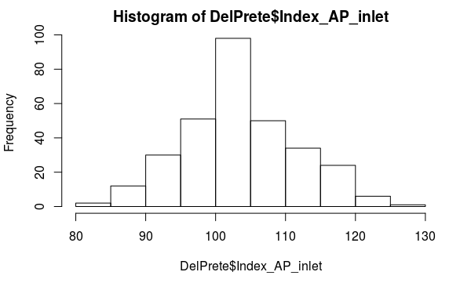

```r
hist(DelPrete$Index_AP_inlet)
```

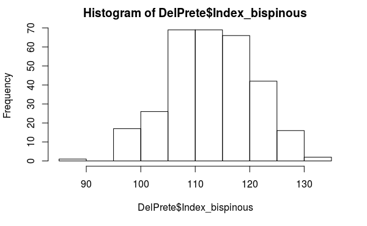

```r
hist(DelPrete$Index_bispinous)
```

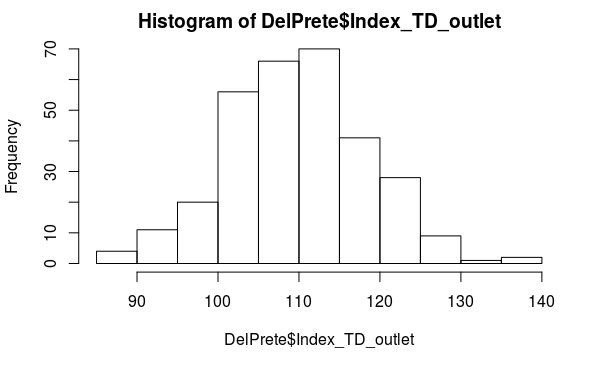

```r
hist(DelPrete$Index_TD_outlet)
```

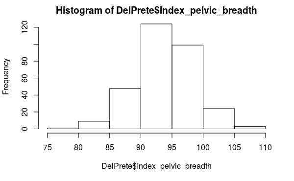

```r
hist(DelPrete$Index_pelvic_breadth)
```

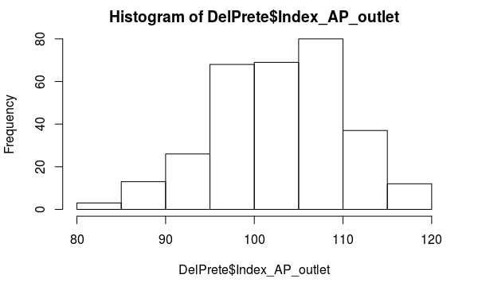

```r
hist(DelPrete$Index_AP_outlet)
```

# 04 02 20

## New Correlations, non linear

```r
#' Computes the rank correlation between to samples
#' @param x vector containing the first sample of data
#' @param y vector containing the second sample of data
#'
#' @return the rank correlation

rankcor <- function(x, y){
  n <- length(x)
  stopifnot(length(y) == n)

  x.ranks <- rank(x)
  y.ranks <- rank(y)

  covariance.term <- cov(x.ranks, y.ranks)

  sd.x <- sqrt((((n^2)-1)/12)*(n/(n-1)))
  sd.y <- sqrt((((n^2)-1)/12)*(n/(n-1)))

  rank.cor <- covariance.term / (sd.x*sd.y)


  return(rank.cor)
}
```

```r
rankcor(DelPreteT$Index_bispinous, DelPreteT$GM)
```

```
[1] 0.05812597
```

```r
cor(DelPrete$Index_bispinous, DelPrete$GM)
```

```
[1] 0.09045264
```

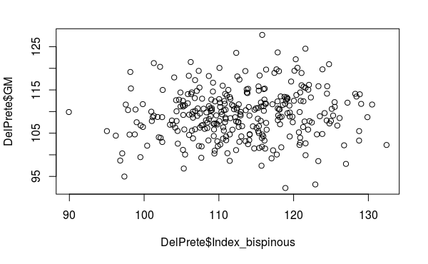

```r
plot(DelPrete$Index_bispinous, DelPrete$GM)
```

```r
rankcor(DelPrete$Index_bispinous, DelPrete$GM)
```

```
[1] 0.1012249
```

```r
Del.response <- list(AP.Inlet = DelPrete$Index_AP_inlet, AP.Outlet = DelPrete$Index_AP_outlet, Bispinous = DelPrete$Index_bispinous, Pelvic.Breadth = DelPrete$Index_pelvic_breadth, TD.Outlet = DelPrete$Index_TD_outlet)

Del.pred <- list(GM = DelPrete$GM, Femur.Head.Adj = DelPrete$femur_head_adjusted_1.715)
length(Del.response)
```

```
[1] 5
```

```r
Del.response[[5]]
```

[output not shown]

[output cut: 29 more lines]

```r
Del.response[5]
```

[output not shown]

[output cut: 30 more lines]

# 4 07 2020

```r
smooth.spline(DelPrete$GM, DelPrete$Index_AP_inlet)
```

```
Call:
smooth.spline(x = DelPrete$GM, y = DelPrete$Index_AP_inlet)

Smoothing Parameter  spar= 1.122768  lambda= 0.01502585 (11 iterations)
Equivalent Degrees of Freedom (Df): 4.665666
Penalized Criterion (RSS): 19303.14
GCV: 65.42422
```

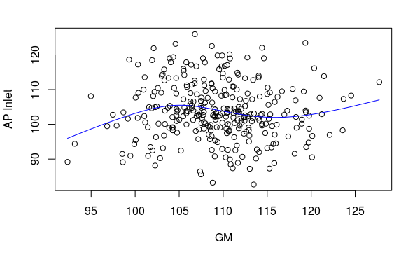

```r
plot(DelPrete$GM, DelPrete$Index_AP_inlet, xlab = "GM", ylab = "AP Inlet")
lines(smooth.spline(DelPrete$GM, DelPrete$Index_AP_inlet), col = "blue")
```

```r
smooth.spline(DelPrete$femur_head_adjusted_1.715, DelPrete$Index_AP_inlet)
```

```
Call:
smooth.spline(x = DelPrete$femur_head_adjusted_1.715, y = DelPrete$Index_AP_inlet)

Smoothing Parameter  spar= 1.499954  lambda= 11.15665 (26 iterations)
Equivalent Degrees of Freedom (Df): 2.023663
Penalized Criterion (RSS): 17375.97
GCV: 67.31662
```

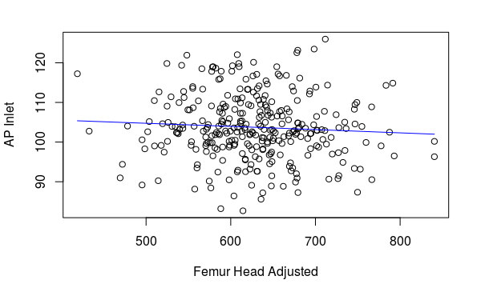

```r
plot(DelPrete$femur_head_adjusted_1.715, DelPrete$Index_AP_inlet, xlab = "Femur Head Adjusted", ylab = "AP Inlet")
lines(smooth.spline(DelPrete$femur_head_adjusted_1.715, DelPrete$Index_AP_inlet), col = "blue")
```

```r
library(mgcv)
```

## AP Inlet

### GM

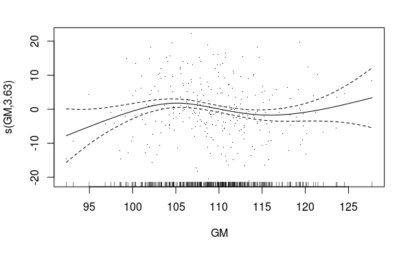

```r
?plot
AP.GM <-gam(Index_AP_inlet ~ s(GM), data = DelPrete)

plot(AP.GM, residuals = TRUE)
```

```r
summary(AP.GM)
```

```
Family: gaussian
Link function: identity

Formula:
Index_AP_inlet ~ s(GM)

Parametric coefficients:
            Estimate Std. Error t value Pr(>|t|)
(Intercept) 103.7313     0.4574   226.8   <2e-16 ***
---
Signif. codes:  0 ‘***’ 0.001 ‘**’ 0.01 ‘*’ 0.05 ‘.’ 0.1 ‘ ’ 1

Approximate significance of smooth terms:
        edf Ref.df    F p-value
s(GM) 3.625  4.588 2.69  0.0255 *
---
Signif. codes:  0 ‘***’ 0.001 ‘**’ 0.01 ‘*’ 0.05 ‘.’ 0.1 ‘ ’ 1

R-sq.(adj) =  0.0377   Deviance explained =  4.9%
GCV = 65.413  Scale est. = 64.43     n = 308
```

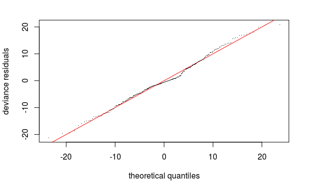

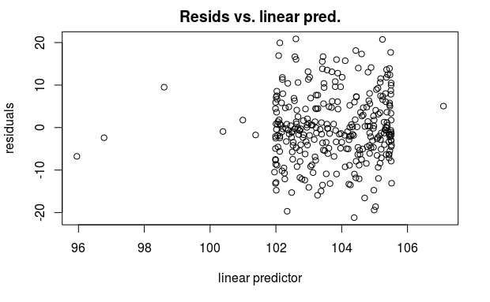

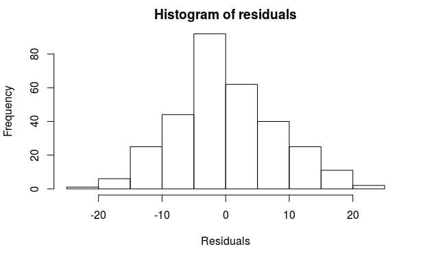

```
Method: GCV   Optimizer: magic
Smoothing parameter selection converged after 4 iterations.
The RMS GCV score gradient at convergence was 2.552518e-05 .
The Hessian was positive definite.
Model rank =  10 / 10

Basis dimension (k) checking results. Low p-value (k-index<1) may
indicate that k is too low, especially if edf is close to k'.

        k'  edf k-index p-value
s(GM) 9.00 3.63    1.04    0.74
```

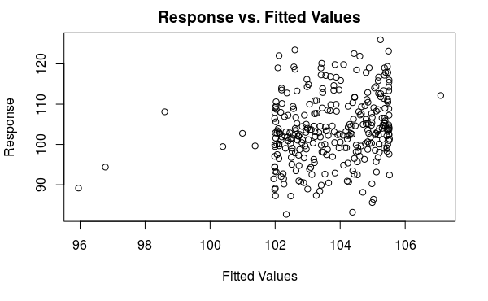

```r
gam.check(AP.GM)
```

```r
cor.test(DelPrete$Index_AP_inlet, DelPrete$GM)
```

```
    Pearson's product-moment correlation

data:  x and y
t = -0.84796, df = 306, p-value = 0.3971
alternative hypothesis: true correlation is not equal to 0
95 percent confidence interval:
 -0.15931404  0.06368532
sample estimates:
       cor
-0.0484177
```

### Femur Head Adj

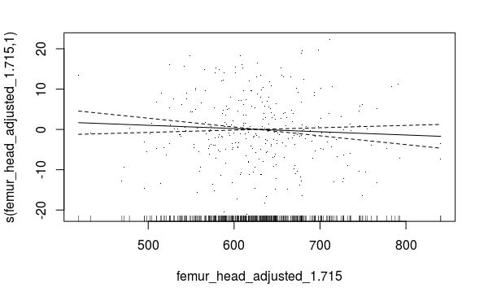

```r
AP.Femur <-gam(Index_AP_inlet ~ s(femur_head_adjusted_1.715), data = DelPrete)

plot(AP.Femur, residuals = TRUE)
```

```r
summary(AP.Femur)
```

```
Family: gaussian
Link function: identity

Formula:
Index_AP_inlet ~ s(femur_head_adjusted_1.715)

Parametric coefficients:
            Estimate Std. Error t value Pr(>|t|)
(Intercept)  103.731      0.466   222.6   <2e-16 ***
---
Signif. codes:  0 ‘***’ 0.001 ‘**’ 0.01 ‘*’ 0.05 ‘.’ 0.1 ‘ ’ 1

Approximate significance of smooth terms:
                             edf Ref.df     F p-value
s(femur_head_adjusted_1.715)   1      1 1.347   0.247

R-sq.(adj) =  0.00113   Deviance explained = 0.438%
GCV = 67.313  Scale est. = 66.876    n = 308
```

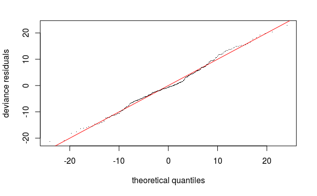

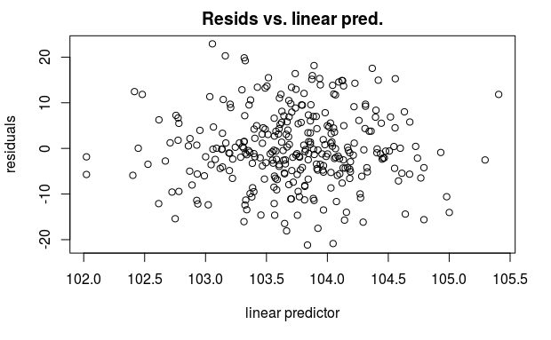

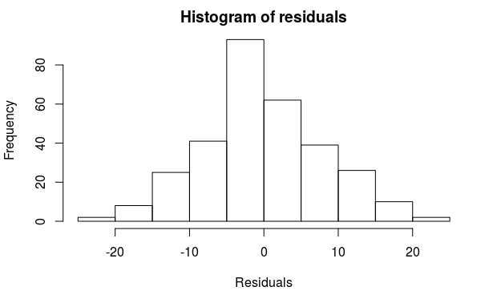

```
Method: GCV   Optimizer: magic
Smoothing parameter selection converged after 11 iterations.
The RMS GCV score gradient at convergence was 4.75565e-06 .
The Hessian was positive definite.
Model rank =  10 / 10

Basis dimension (k) checking results. Low p-value (k-index<1) may
indicate that k is too low, especially if edf is close to k'.

                             k' edf k-index p-value
s(femur_head_adjusted_1.715)  9   1       1    0.43
```

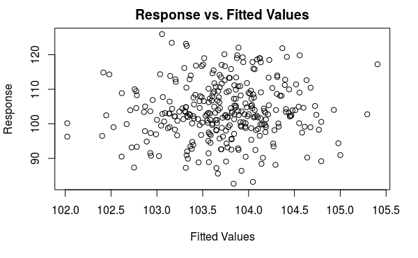

```r
gam.check(AP.Femur)
```

```r
cor.test(DelPrete$Index_AP_inlet, DelPrete$femur_head_adjusted_1.715)
```

```
    Pearson's product-moment correlation

data:  x and y
t = -1.1604, df = 306, p-value = 0.2468
alternative hypothesis: true correlation is not equal to 0
95 percent confidence interval:
 -0.1766438  0.0459059
sample estimates:
       cor
-0.0661921
```

## TD Outlet

### GM

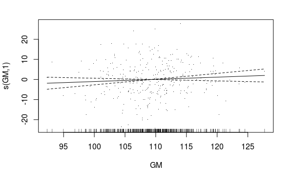

```r
TD.OUT.GM <-gam(Index_TD_outlet ~ s(GM), data = DelPrete)

plot(TD.OUT.GM, residuals = TRUE)
```

```r
summary(TD.OUT.GM)
```

```
Family: gaussian
Link function: identity

Formula:
Index_TD_outlet ~ s(GM)

Parametric coefficients:
            Estimate Std. Error t value Pr(>|t|)
(Intercept)  109.951      0.498   220.8   <2e-16 ***
---
Signif. codes:  0 ‘***’ 0.001 ‘**’ 0.01 ‘*’ 0.05 ‘.’ 0.1 ‘ ’ 1

Approximate significance of smooth terms:
      edf Ref.df     F p-value
s(GM)   1      1 1.544   0.215

R-sq.(adj) =  0.00177   Deviance explained = 0.502%
GCV = 76.886  Scale est. = 76.387    n = 308
```

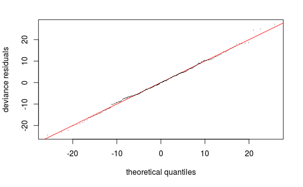

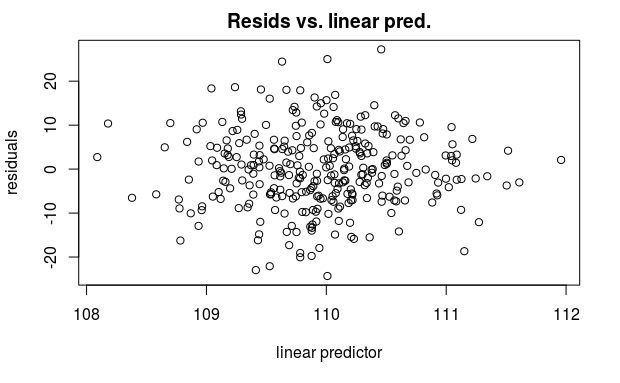

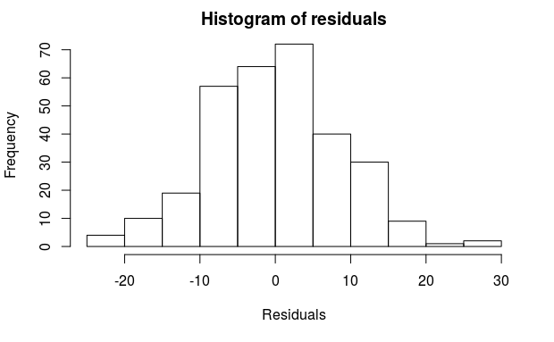

```
Method: GCV   Optimizer: magic
Smoothing parameter selection converged after 13 iterations.
The RMS GCV score gradient at convergence was 1.001808e-05 .
The Hessian was positive definite.
Model rank =  10 / 10

Basis dimension (k) checking results. Low p-value (k-index<1) may
indicate that k is too low, especially if edf is close to k'.

      k' edf k-index p-value
s(GM)  9   1     1.1    0.98
```

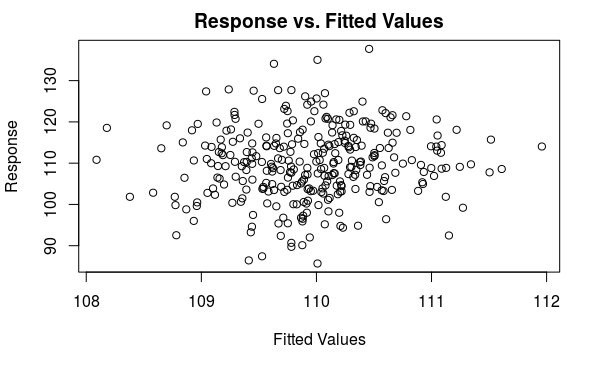

```r
gam.check(TD.OUT.GM)
```

```r
cor.test(DelPrete$Index_TD_outlet, DelPrete$GM)
```

```
    Pearson's product-moment correlation

data:  x and y
t = 1.2426, df = 306, p-value = 0.215
alternative hypothesis: true correlation is not equal to 0
95 percent confidence interval:
 -0.0412273  0.1811812
sample estimates:
       cor
0.07085759
```

### Femur Head Adj

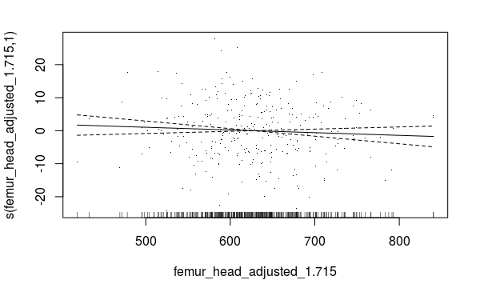

```r
TD.OUT.Femur <-gam(Index_TD_outlet ~ s(femur_head_adjusted_1.715), data = DelPrete)

plot(TD.OUT.Femur, residuals = TRUE)
```

```r
summary(TD.OUT.Femur)
```

```
Family: gaussian
Link function: identity

Formula:
Index_TD_outlet ~ s(femur_head_adjusted_1.715)

Parametric coefficients:
            Estimate Std. Error t value Pr(>|t|)
(Intercept) 109.9508     0.4983   220.7   <2e-16 ***
---
Signif. codes:  0 ‘***’ 0.001 ‘**’ 0.01 ‘*’ 0.05 ‘.’ 0.1 ‘ ’ 1

Approximate significance of smooth terms:
                             edf Ref.df     F p-value
s(femur_head_adjusted_1.715)   1      1 1.221    0.27

R-sq.(adj) =  0.00072   Deviance explained = 0.397%
GCV = 76.967  Scale est. = 76.467    n = 308
```

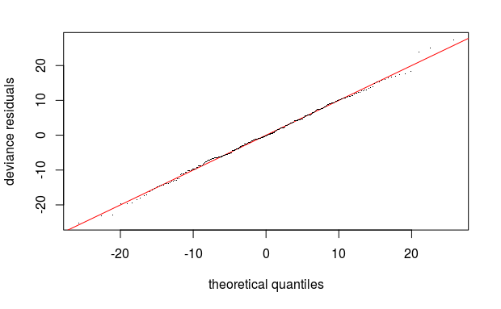

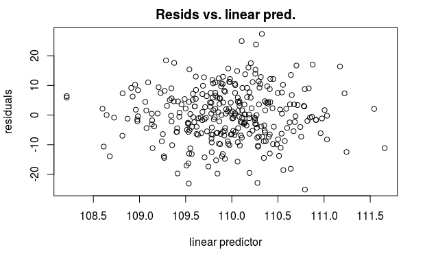

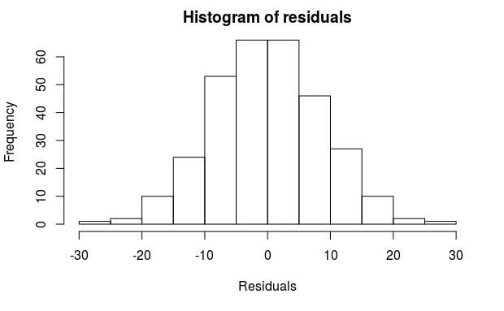

```
Method: GCV   Optimizer: magic
Smoothing parameter selection converged after 12 iterations.
The RMS GCV score gradient at convergence was 5.202205e-06 .
The Hessian was positive definite.
Model rank =  10 / 10

Basis dimension (k) checking results. Low p-value (k-index<1) may
indicate that k is too low, especially if edf is close to k'.

                             k' edf k-index p-value
s(femur_head_adjusted_1.715)  9   1    0.95    0.15
```

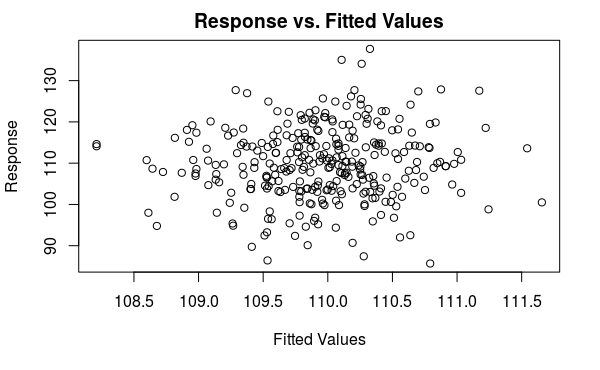

```r
gam.check(TD.OUT.Femur)
```

```r
cor.test(DelPrete$Index_TD_outlet, DelPrete$femur_head_adjusted_1.715)
```

```
    Pearson's product-moment correlation

data:  x and y
t = -1.1051, df = 306, p-value = 0.27
alternative hypothesis: true correlation is not equal to 0
95 percent confidence interval:
 -0.17358125  0.04905819
sample estimates:
        cor
-0.06304588
```

## AP Outlet

### GM

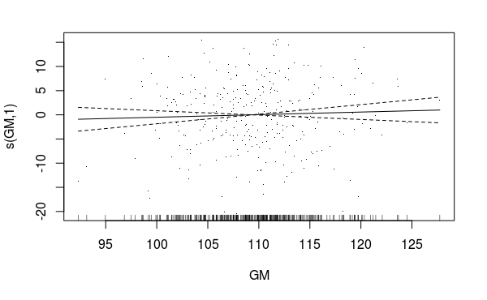

```r
AP.OUT.GM <-gam(Index_AP_outlet ~ s(GM), data = DelPrete)

plot(AP.OUT.GM, residuals = TRUE)
```

```r
summary(AP.OUT.GM)
```

```
Family: gaussian
Link function: identity

Formula:
Index_AP_outlet ~ s(GM)

Parametric coefficients:
            Estimate Std. Error t value Pr(>|t|)
(Intercept) 102.6999     0.4083   251.5   <2e-16 ***
---
Signif. codes:  0 ‘***’ 0.001 ‘**’ 0.01 ‘*’ 0.05 ‘.’ 0.1 ‘ ’ 1

Approximate significance of smooth terms:
      edf Ref.df     F p-value
s(GM)   1      1 0.555   0.457

R-sq.(adj) =  -0.00145   Deviance explained = 0.181%
GCV = 51.676  Scale est. = 51.341    n = 308
```

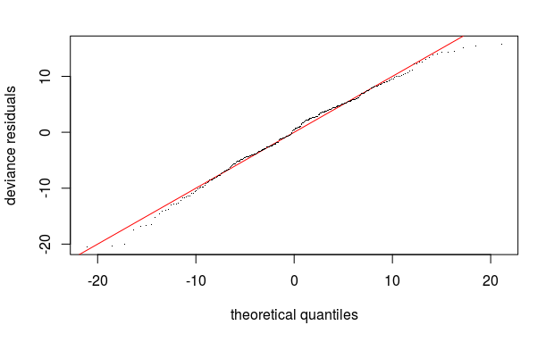

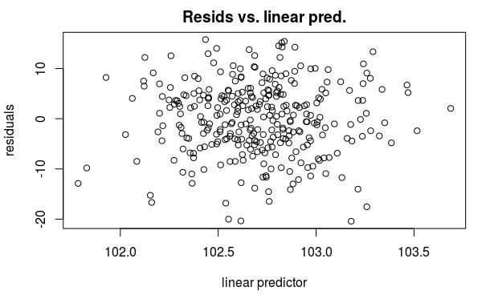

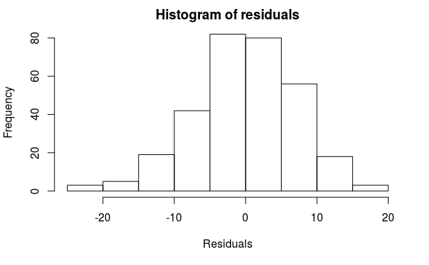

```
Method: GCV   Optimizer: magic
Smoothing parameter selection converged after 11 iterations.
The RMS GCV score gradient at convergence was 3.522416e-06 .
The Hessian was positive definite.
Model rank =  10 / 10

Basis dimension (k) checking results. Low p-value (k-index<1) may
indicate that k is too low, especially if edf is close to k'.

      k' edf k-index p-value
s(GM)  9   1    1.12    0.98
```

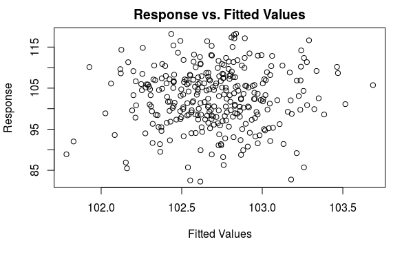

```r
gam.check(AP.OUT.GM)
```

```r
cor.test(DelPrete$Index_AP_outlet, DelPrete$GM)
```

```
    Pearson's product-moment correlation

data:  x and y
t = 0.74529, df = 306, p-value = 0.4567
alternative hypothesis: true correlation is not equal to 0
95 percent confidence interval:
 -0.06952214  0.15359472
sample estimates:
       cor
0.04256699
```

### Femur Head Adj

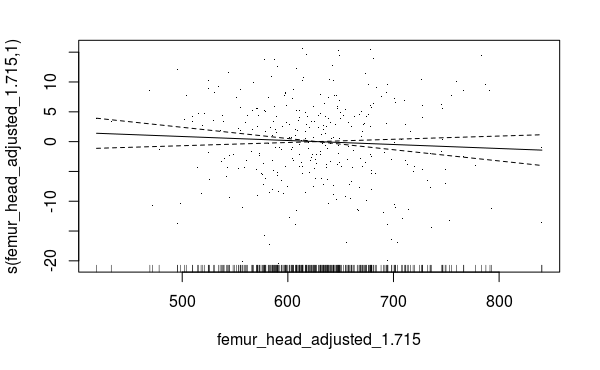

```r
AP.OUT.Femur <-gam(Index_AP_outlet ~ s(femur_head_adjusted_1.715), data = DelPrete)

plot(AP.OUT.Femur, residuals = TRUE)
```

```r
summary(AP.OUT.Femur)
```

```
Family: gaussian
Link function: identity

Formula:
Index_AP_outlet ~ s(femur_head_adjusted_1.715)

Parametric coefficients:
            Estimate Std. Error t value Pr(>|t|)
(Intercept) 102.6999     0.4078   251.8   <2e-16 ***
---
Signif. codes:  0 ‘***’ 0.001 ‘**’ 0.01 ‘*’ 0.05 ‘.’ 0.1 ‘ ’ 1

Approximate significance of smooth terms:
                             edf Ref.df     F p-value
s(femur_head_adjusted_1.715)   1      1 1.227   0.269

R-sq.(adj) =  0.00074   Deviance explained = 0.399%
GCV = 51.563  Scale est. = 51.229    n = 308
```

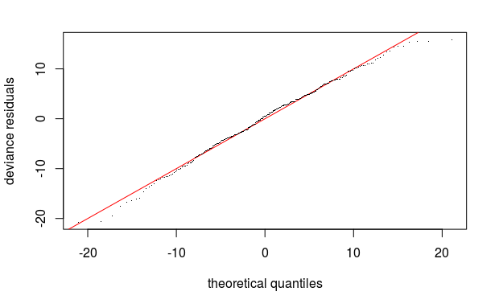

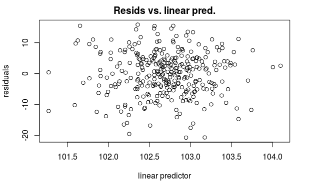

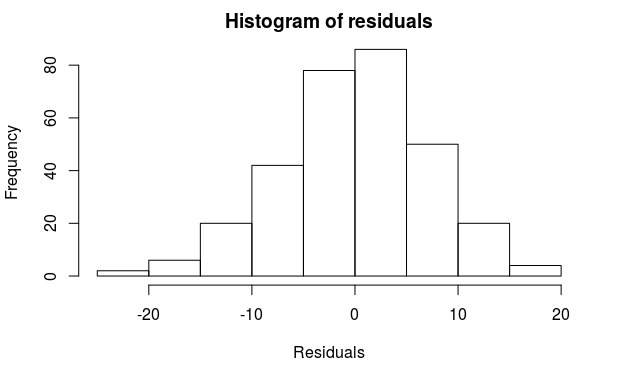

```
Method: GCV   Optimizer: magic
Smoothing parameter selection converged after 12 iterations.
The RMS GCV score gradient at convergence was 3.450972e-06 .
The Hessian was positive definite.
Model rank =  10 / 10

Basis dimension (k) checking results. Low p-value (k-index<1) may
indicate that k is too low, especially if edf is close to k'.

                             k' edf k-index p-value
s(femur_head_adjusted_1.715)  9   1    1.05    0.78
```

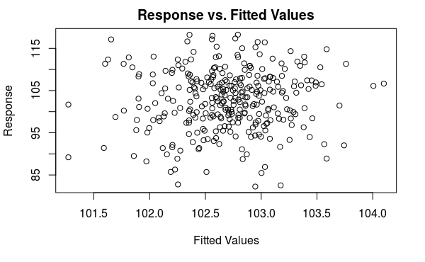

```r
gam.check(AP.OUT.Femur)
```

```r
cor.test(DelPrete$Index_AP_outlet, DelPrete$femur_head_adjusted_1.715)
```

```
    Pearson's product-moment correlation

data:  x and y
t = -1.1078, df = 306, p-value = 0.2688
alternative hypothesis: true correlation is not equal to 0
95 percent confidence interval:
 -0.17373435  0.04890071
sample estimates:
        cor
-0.06320311
```

## Bispinous

### GM

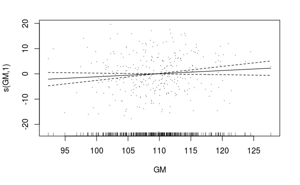

```r
Bispi.GM <-gam(Index_bispinous ~ s(GM), data = DelPrete)

plot(Bispi.GM, residuals = TRUE)
```

```r
summary(Bispi.GM)
```

```
Family: gaussian
Link function: identity

Formula:
Index_bispinous ~ s(GM)

Parametric coefficients:
            Estimate Std. Error t value Pr(>|t|)
(Intercept) 112.8588     0.4382   257.5   <2e-16 ***
---
Signif. codes:  0 ‘***’ 0.001 ‘**’ 0.01 ‘*’ 0.05 ‘.’ 0.1 ‘ ’ 1

Approximate significance of smooth terms:
      edf Ref.df     F p-value
s(GM)   1      1 2.524   0.113

R-sq.(adj) =  0.00494   Deviance explained = 0.818%
GCV = 59.536  Scale est. = 59.15     n = 308
```

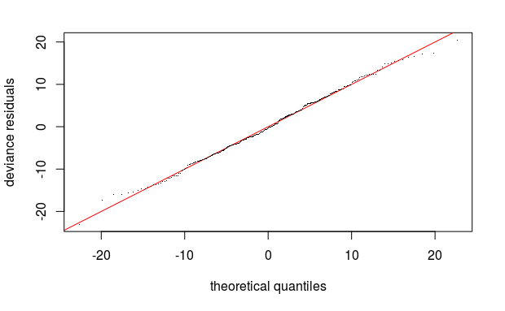

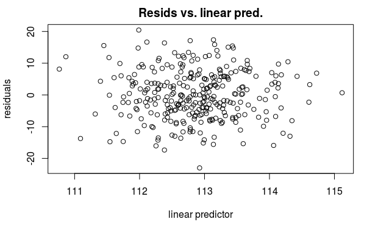

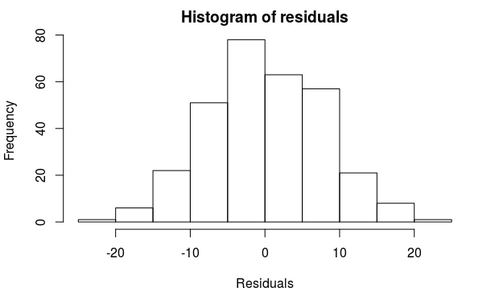

```
Method: GCV   Optimizer: magic
Smoothing parameter selection converged after 10 iterations.
The RMS GCV score gradient at convergence was 9.273221e-06 .
The Hessian was positive definite.
Model rank =  10 / 10

Basis dimension (k) checking results. Low p-value (k-index<1) may
indicate that k is too low, especially if edf is close to k'.

      k' edf k-index p-value
s(GM)  9   1    1.13       1
```

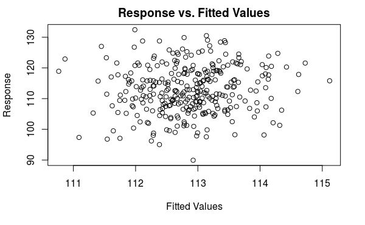

```r
gam.check(Bispi.GM)
```

```r
cor.test(DelPrete$Index_bispinous, DelPrete$GM)
```

```
    Pearson's product-moment correlation

data:  x and y
t = 1.5888, df = 306, p-value = 0.1131
alternative hypothesis: true correlation is not equal to 0
95 percent confidence interval:
 -0.02152334  0.20018739
sample estimates:
       cor
0.09045264
```

### Femur Head Adj

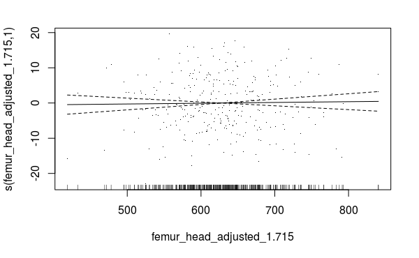

```r
Bispi.Femur <-gam(Index_bispinous ~ s(femur_head_adjusted_1.715), data = DelPrete)

plot(Bispi.Femur, residuals = TRUE)
```

```r
summary(Bispi.Femur)
```

```
Family: gaussian
Link function: identity

Formula:
Index_bispinous ~ s(femur_head_adjusted_1.715)

Parametric coefficients:
            Estimate Std. Error t value Pr(>|t|)
(Intercept)   112.86       0.44   256.5   <2e-16 ***
---
Signif. codes:  0 ‘***’ 0.001 ‘**’ 0.01 ‘*’ 0.05 ‘.’ 0.1 ‘ ’ 1

Approximate significance of smooth terms:
                             edf Ref.df     F p-value
s(femur_head_adjusted_1.715)   1      1 0.111   0.739

R-sq.(adj) =  -0.0029   Deviance explained = 0.0362%
GCV = 60.006  Scale est. = 59.616    n = 308
```

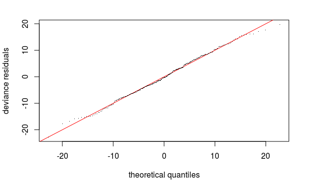

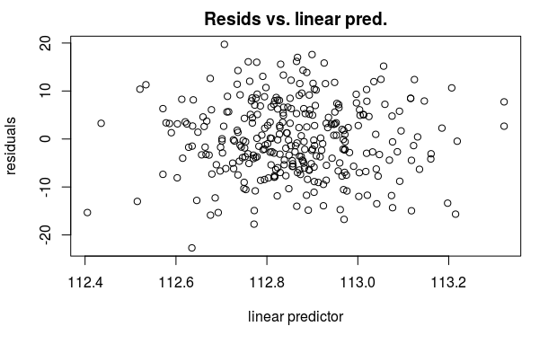

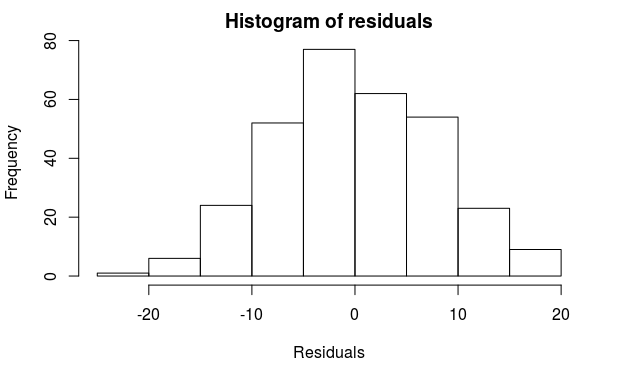

```
Method: GCV   Optimizer: magic
Smoothing parameter selection converged after 11 iterations.
The RMS GCV score gradient at convergence was 4.015525e-06 .
The Hessian was positive definite.
Model rank =  10 / 10

Basis dimension (k) checking results. Low p-value (k-index<1) may
indicate that k is too low, especially if edf is close to k'.

                             k' edf k-index p-value
s(femur_head_adjusted_1.715)  9   1    0.97    0.23
```

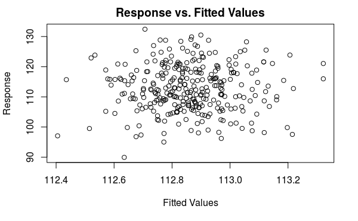

```r
gam.check(Bispi.Femur)
```

```r
cor.test(DelPrete$Index_bispinous, DelPrete$femur_head_adjusted_1.715)
```

```
    Pearson's product-moment correlation

data:  x and y
t = 0.33296, df = 306, p-value = 0.7394
alternative hypothesis: true correlation is not equal to 0
95 percent confidence interval:
 -0.09292557  0.13051131
sample estimates:
       cor
0.01903047
```

## Pelvic Breadth

### GM

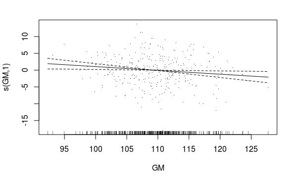

```r
PB.GM <-gam(Index_pelvic_breadth ~ s(GM), data = DelPrete)

plot(PB.GM, residuals = TRUE)
```

```r
summary(PB.GM)
```

```
Family: gaussian
Link function: identity

Formula:
Index_pelvic_breadth ~ s(GM)

Parametric coefficients:
            Estimate Std. Error t value Pr(>|t|)
(Intercept)  93.9082     0.2604   360.6   <2e-16 ***
---
Signif. codes:  0 ‘***’ 0.001 ‘**’ 0.01 ‘*’ 0.05 ‘.’ 0.1 ‘ ’ 1

Approximate significance of smooth terms:
      edf Ref.df    F p-value
s(GM)   1      1 6.06  0.0144 *
---
Signif. codes:  0 ‘***’ 0.001 ‘**’ 0.01 ‘*’ 0.05 ‘.’ 0.1 ‘ ’ 1

R-sq.(adj) =  0.0162   Deviance explained = 1.94%
GCV = 21.026  Scale est. = 20.89     n = 308
```

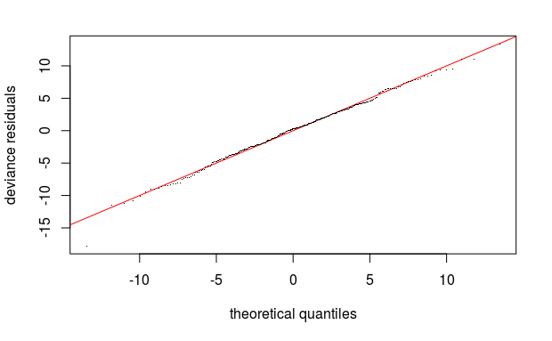

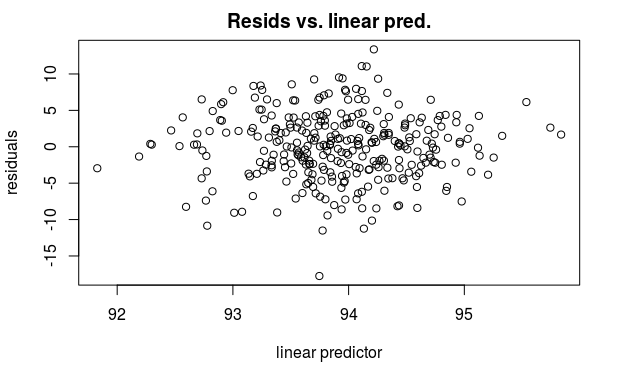

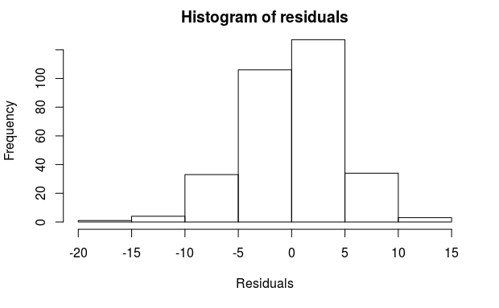

```
Method: GCV   Optimizer: magic
Smoothing parameter selection converged after 12 iterations.
The RMS GCV score gradient at convergence was 1.853947e-06 .
The Hessian was positive definite.
Model rank =  10 / 10

Basis dimension (k) checking results. Low p-value (k-index<1) may
indicate that k is too low, especially if edf is close to k'.

      k' edf k-index p-value
s(GM)  9   1    1.14    0.98
```

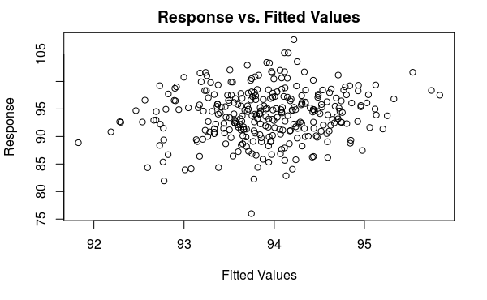

```r
gam.check(PB.GM)
```

```r
cor.test(DelPrete$Index_pelvic_breadth, DelPrete$GM)
```

```
    Pearson's product-moment correlation

data:  x and y
t = -2.4617, df = 306, p-value = 0.01438
alternative hypothesis: true correlation is not equal to 0
95 percent confidence interval:
 -0.2472603 -0.0280308
sample estimates:
       cor
-0.1393527
```